# Advanced Trees with Wages Data

Trees are flexible and easy to understand but tend to overfit and do not have the same level of predictive accuracy as other prediction models. In the following sections, we will examine a number of ways to improve tree models including tuning tree hyperparameters, and ensemble models such as bagging, forests, and boosting.

# Data Description

Wages dataset is a simulated dataset based on a real dataset published in Data Analysis using Regression and Multilevel/Hierarchical Models by Andrew Gelman and Jennifer Hill

Data consists of characteristics of a set of employees and their annual earning. Variables included are:

- earn: Annual earning in dollars
- height: Height in inches
- gender: Gender (male, female)
- race: african-american, asian, hispanic, white
- ed: Years of education
- age: Age in years

# Read Data

Set your working directory to the location where the data is saved by adapting the code below.

```r
setwd('c:/my_classes/best_course_ever/') # on Windows
setwd('/my_classes/best_course_ever/') # on Mac
```

```r
data = read.csv('wages.csv', stringsAsFactors = T)
data = data[data$earn>0,]
```

# Split Data

```r
set.seed(617)
split = sample(1:nrow(data),size = nrow(data)*0.8)
train = data[split,]
test = data[-split,]
```

In the following sections, we will build a series of models, in some cases tune them and then evaluate them on the test data.

# Tree Models

## Default Tree

The default value of cp is 0.01

```r
library(rpart); library(rpart.plot)
tree = rpart(earn~.,data=train)
pred = predict(tree,newdata=test)
rmse_tree = sqrt(mean((pred-test$earn)^2)); rmse_tree
```

```
## [1] 53456.15
```

## Maximal Tree

This is the largest possible tree.

```r
maximalTree = rpart(earn~.,data=train,control=rpart.control(cp=0))
pred = predict(maximalTree,newdata=test)
rmse_maximalTree = sqrt(mean((pred-test$earn)^2)); rmse_maximalTree
```

```
## [1] 57082.55
```

## Tree with Tuning

Tune the complexity of a tree using 5-fold cross-validation. Here, we will examine cross-validation error for 100 different values of cp.

```r
library(caret)
trControl = trainControl(method='cv',number = 5)
tuneGrid = expand.grid(.cp = seq(from = 0.001,to = 0.1,by = 0.001))
set.seed(617)
cvModel = train(earn~.,
                data=train,
                method="rpart",
                trControl = trControl,
                tuneGrid = tuneGrid)

cvModel$results
```

|  | cp | RMSE | Rsquared | MAE | RMSESD | RsquaredSD | MAESD |
| --- | --- | --- | --- | --- | --- | --- | --- |
| 1 | 0.001 | 58109.24 | 0.2205979 | 38289.82 | 4096.196 | 0.07289116 | 1409.1612 |
| 2 | 0.002 | 57854.68 | 0.2199231 | 38122.92 | 4255.585 | 0.08119947 | 1296.6183 |
| 3 | 0.003 | 57652.57 | 0.2201436 | 37787.52 | 4114.090 | 0.08668704 | 950.9004 |
| 4 | 0.004 | 57060.70 | 0.2261675 | 37474.47 | 4554.308 | 0.09144301 | 1385.1958 |
| 5 | 0.005 | 57131.09 | 0.2219554 | 37442.13 | 4730.652 | 0.08875365 | 1543.5813 |
| 6 | 0.006 | 56934.97 | 0.2236642 | 37421.03 | 4850.358 | 0.09632551 | 1327.4715 |
| 7 | 0.007 | 57017.74 | 0.2202879 | 37609.53 | 4789.538 | 0.09650538 | 1192.7217 |
| 8 | 0.008 | 56658.25 | 0.2274475 | 37378.90 | 4468.495 | 0.09804062 | 878.6218 |
| 9 | 0.009 | 56704.22 | 0.2259959 | 37435.16 | 4548.977 | 0.09891671 | 999.5121 |
| 10 | 0.010 | 56605.38 | 0.2257526 | 37498.57 | 4477.987 | 0.09881983 | 980.0040 |

[output cut: 90 more lines]

Results from Tuning

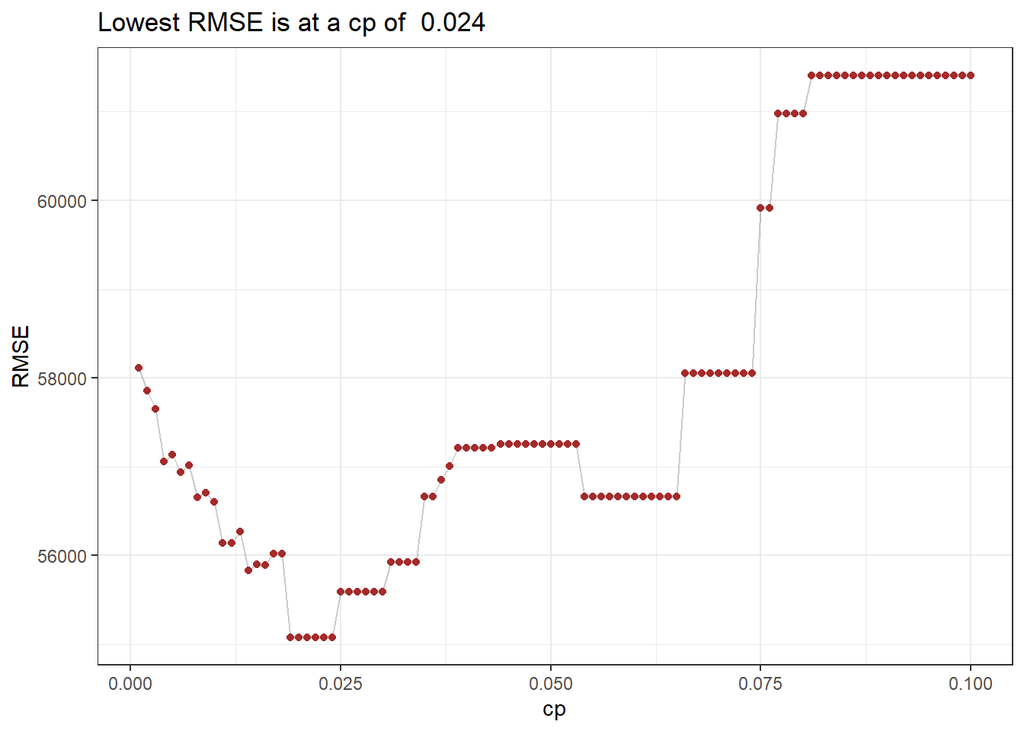

```r
library(ggplot2)
ggplot(data=cvModel$results, aes(x=cp, y=RMSE))+
  geom_line(size=0.5,alpha=0.2)+
  geom_point(color='brown')+
  theme_bw()+
  ggtitle(label=paste('Lowest RMSE is at a cp of ',cvModel$bestTune$cp))
```

Evaluate Tuned model on Test sample

```r
cvTree = rpart(earn~.,data=train,cp = cvModel$bestTune$cp)
pred = predict(cvTree,newdata=test)
rmse_cvTree = sqrt(mean((pred-test$earn)^2)); rmse_cvTree
```

```
## [1] 54198.35
```

# Ensemble Models

- Bagging
- Forest
- Boosting

# Bag Models

Bootstrap Aggregation models generate a large number of bootstrapped samples. A tree is fit to each bootstrapped sample. Predictions are generating as an average of all models (for numerical outcome variables) or the majority group (for categorical outcome variables).

These models can be implemented using many packages including ipred, randomForest,adabag, bagEarth, treeBag, bagFDA. In this illustration, we are using a randomForest model by setting mtry to be the number of predictors, i.e., 5.

```r
library(randomForest)
set.seed(617)
bag = randomForest(earn~.,data=train,mtry = ncol(train)-1,ntree=1000)
pred = predict(bag,newdata=test)
rmse_bag = sqrt(mean((pred-test$earn)^2)); rmse_bag
```

```
## [1] 53486.83
```

The various trees that were fit vary in their size

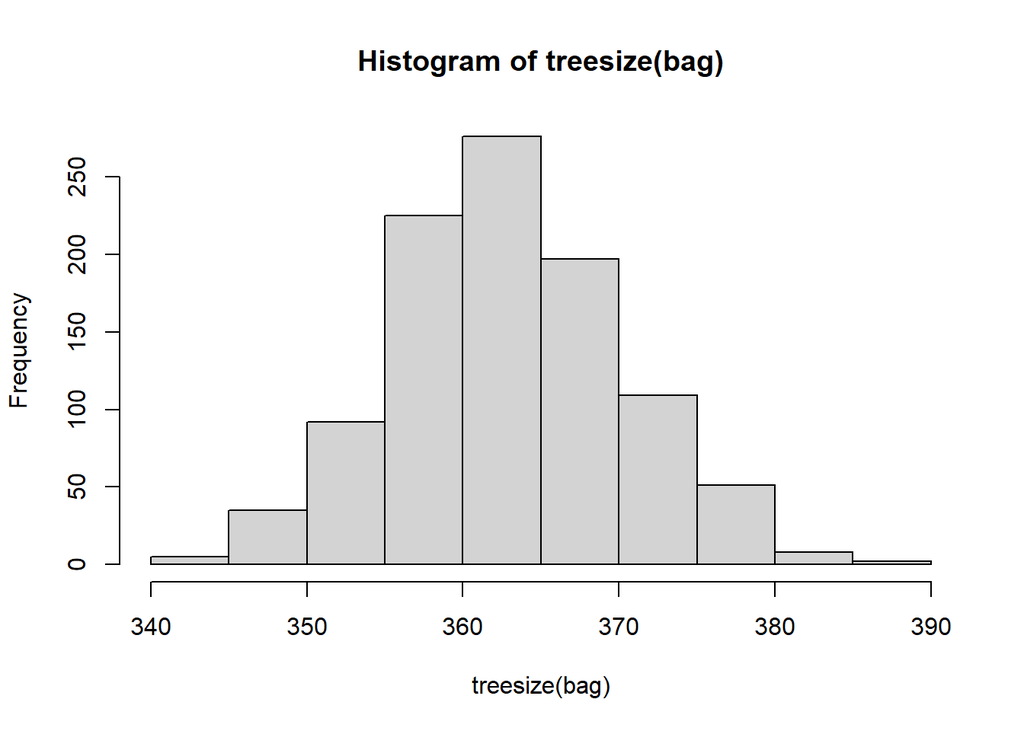

```r
hist(treesize(bag))
```

```r
# getTree(bag,k=100)   # One can examine a given tree
```

Generally speaking, error for a bag model decreases with an increase in the trees.

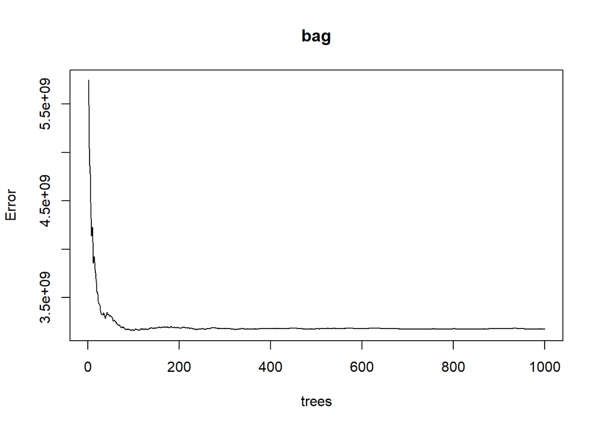

```r
plot(bag)
```

Relative importance of predictors

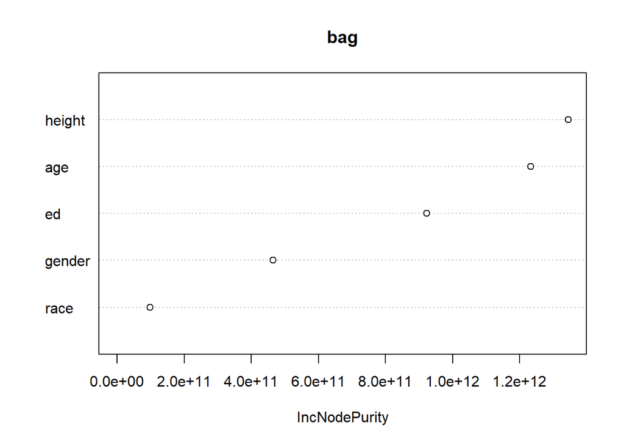

```r
varImpPlot(bag)
```

```r
importance(bag)
```

```
##        IncNodePurity
## height  1.344749e+12
## gender  4.649394e+11
## race    9.759492e+10
## ed      9.227044e+11
## age     1.233138e+12
```

# Random Forest Models

Unlike bag models which consider all predictors in constructing each tree, randomForest models consider a subset of predictors (default is p/3 for numerical outcomes or sqrt(p) for categorical outcomes) for constructing each tree. In `library(randomForest)`, mtry controls number of variables considered for each tree.

```r
library(randomForest)
set.seed(617)
forest = randomForest(earn~.,data=train,ntree = 1000)
pred = predict(forest,newdata=test)
rmse_forest = sqrt(mean((pred-test$earn)^2)); rmse_forest
```

```
## [1] 50062.28
```

As in the case for bags, more trees reduces error to a certain point, after which the graph asymptotes.

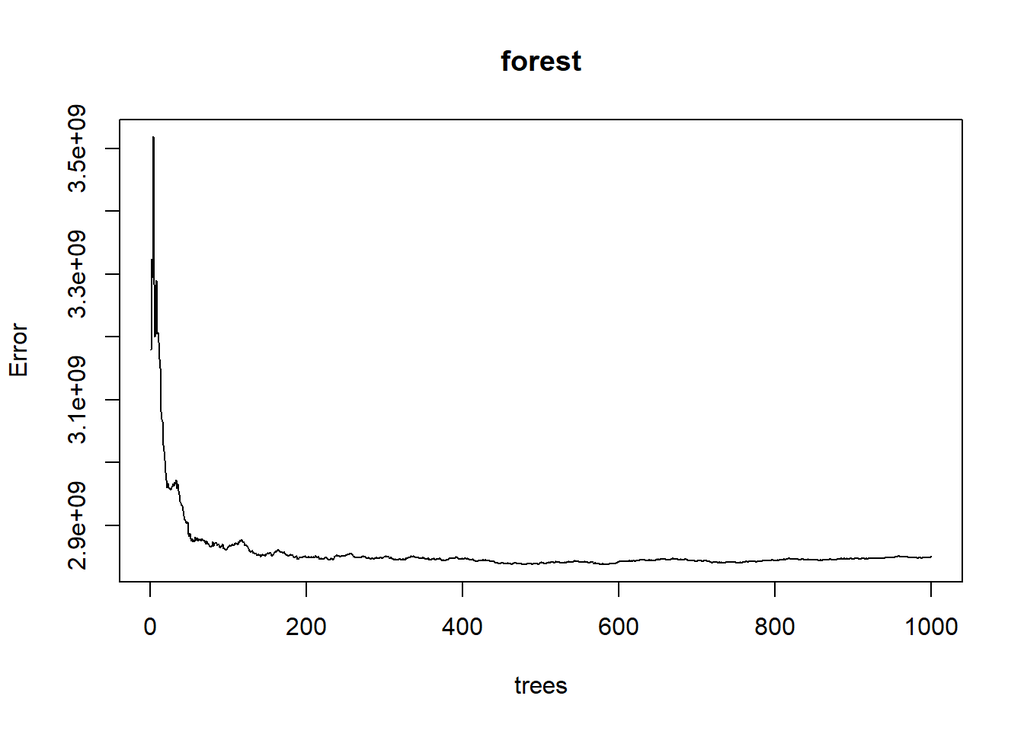

```r
plot(forest)
```

Relative importance of predictors

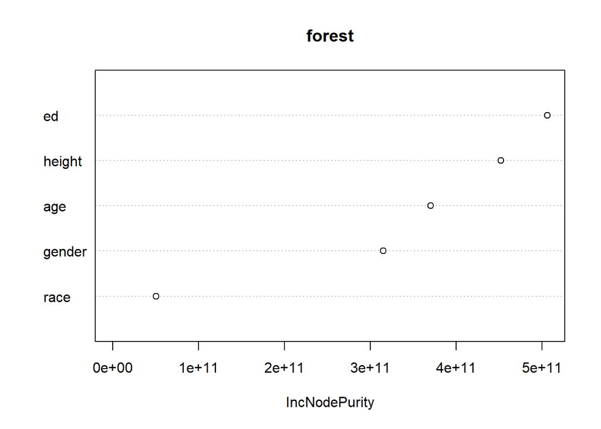

```r
varImpPlot(forest)
```

## Tuned Random Forest

The mtry parameter of a randomForest model can be tuned to improve model predictions. Here, we will use 5-fold cross validation to examine four values of mtry.

```r
trControl=trainControl(method="cv",number=5)
tuneGrid = expand.grid(mtry=1:4)
set.seed(617)
cvModel = train(earn~.,data=train,
                 method="rf",ntree=1000,trControl=trControl,tuneGrid=tuneGrid )
cvModel
```

```
## Random Forest
##
## 1094 samples
##    5 predictor
##
## No pre-processing
## Resampling: Cross-Validated (5 fold)
## Summary of sample sizes: 875, 875, 875, 876, 875
## Resampling results across tuning parameters:
##
##   mtry  RMSE      Rsquared   MAE
##   1     55791.64  0.2891217  36982.68
##   2     53265.49  0.3015901  35135.91
##   3     54021.84  0.2856715  35466.80
##   4     55117.06  0.2680037  36034.66
##
## RMSE was used to select the optimal model using the smallest value.
## The final value used for the model was mtry = 2.
```

Now, let us use the best mtry of 2.

```r
cvForest = randomForest(earn~.,data=train,ntree = 1000,mtry=cvModel$bestTune$mtry)
pred = predict(cvForest,newdata=test)
rmse_cv_forest = sqrt(mean((pred-test$earn)^2)); rmse_cv_forest
```

```
## [1] 52363.92
```

## Forest with Ranger

ranger is popular R library for running random forest models.

```r
library(ranger)
forest_ranger = ranger(earn~.,data=train,num.trees = 1000)
pred = predict(forest_ranger, data =test,num.trees = 1000)
rmse_forest_ranger = sqrt(mean((pred$predictions-test$earn)^2)); rmse_forest_ranger
```

```
## [1] 52381.18
```

## Tuned Forest Ranger

Tuning ranger model for different values of mtry, splitrule and min.node.size

```r
trControl=trainControl(method="cv",number=5)
tuneGrid = expand.grid(mtry=1:4,
                       splitrule = c('variance','extratrees','maxstat'),
                       min.node.size = c(2,5,10,15,20,25))
set.seed(617)
cvModel = train(earn~.,
                data=train,
                method="ranger",
                num.trees=1000,
                trControl=trControl,
                tuneGrid=tuneGrid )
cv_forest_ranger = ranger(earn~.,
                          data=train,
                          num.trees = 1000,
                          mtry=cvModel$bestTune$mtry,
                          min.node.size = cvModel$bestTune$min.node.size,
                          splitrule = cvModel$bestTune$splitrule)
pred = predict(cv_forest_ranger, data =test, num.trees = 1000)
rmse_cv_forest_ranger = sqrt(mean((pred$predictions-test$earn)^2)); rmse_cv_forest_ranger
```

```
## [1] 51741.44
```

# Boosting Models

Like bag and forest models, boosting models are ensemble models that derive predictions from a number of trees. The key difference is that in boosting, trees are grown sequentially, each tree is grown using information from previously grown trees. Thus, boosting can be seen as a slow learning evolutionary model. Since we are predicting a numerical variable, earn, the distribution is set to ‘gaussian’. Had the goal been to predict a binary outcome, we would have set distribution to ‘bernoulli’.

```r
library(gbm)
set.seed(617)
boost = gbm(earn~.,
            data=train,
            distribution="gaussian",
            n.trees = 500,
            interaction.depth = 2,
            shrinkage = 0.01)
```

Boosting models offer a way to examine the relative influence of variables.

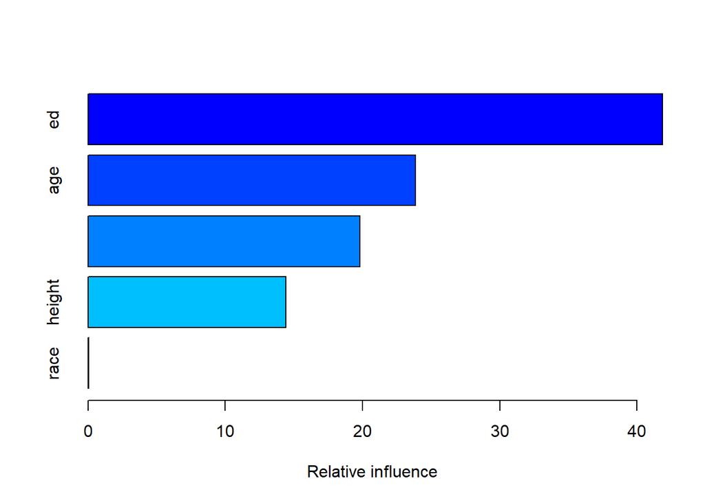

|  | var | rel.inf |
| --- | --- | --- |
| ed | ed | 41.85723381 |
| age | age | 23.85348758 |
| gender | gender | 19.82020900 |
| height | height | 14.41961849 |
| race | race | 0.04945111 |

```r
summary(boost)
```

Let us examine RMSE for the train sample.

```r
pred = predict(boost,n.trees = 500)
rmse_boost_train = sqrt(mean((pred-train$earn)^2)); rmse_boost_train
```

```
## [1] 50425.2
```

Now, examine RMSE for test sample.

```r
pred = predict(boost,newdata=test,n.trees = 500)
rmse_boost = sqrt(mean((pred-test$earn)^2)); rmse_boost
```

```
## [1] 50876.59
```

## Boosting with cross-validation

Boosting models are notorious for overfitting training data. A very simple way to see this borne out is to see the effect of increasing number of trees on train and test rmse. Specifically, in the model above, try running the models with the following number of trees: 200, 1e3, 1e4, 1e6. To avoid the folly of overfitting, it is best to tune the model using cross-validation. In the code that follows, we will tune a gradient boosting model using interaction depth, shrinkage and minobsinnode.

The code below uses a garbage collector to hide from us the long list of models tested.

```r
library(caret)
set.seed(617)
trControl = trainControl(method="cv",number=5)
tuneGrid = expand.grid(n.trees = 500,
                       interaction.depth = c(1,2,3),
                       shrinkage = (1:100)*0.001,
                       n.minobsinnode=c(5,10,15))
garbage = capture.output(cvModel <- train(earn~.,
                                          data=train,
                                          method="gbm",
                                          trControl=trControl,
                                          tuneGrid=tuneGrid))
set.seed(617)
cvBoost = gbm(earn~.,
              data=train,
              distribution="gaussian",
              n.trees=cvModel$bestTune$n.trees,
              interaction.depth=cvModel$bestTune$interaction.depth,
              shrinkage=cvModel$bestTune$shrinkage,
              n.minobsinnode = cvModel$bestTune$n.minobsinnode)
pred = predict(cvBoost,test,n.trees=500)
rmse_cv_boost = sqrt(mean((pred-test$earn)^2)); rmse_cv_boost
```

```
## [1] 51234.84
```

## Boosting with xgboost

XGBoost is an optimized distributed gradient boosting library designed to be highly efficient, flexible and portable.

The algorithm is also a bit picky about the format of variables used. All factor class variables need to be dummy coded and fed into the model as a matrix. To do this, we will dummy code using library(vtreat)

```r
library(vtreat)
trt = designTreatmentsZ(dframe = train,
                        varlist = names(train)[2:6])
```

```
## [1] "vtreat 1.6.3 inspecting inputs Wed Sep 01 16:55:10 2021"
## [1] "designing treatments Wed Sep 01 16:55:10 2021"
## [1] " have initial level statistics Wed Sep 01 16:55:10 2021"
## [1] " scoring treatments Wed Sep 01 16:55:10 2021"
## [1] "have treatment plan Wed Sep 01 16:55:10 2021"
```

```r
newvars = trt$scoreFrame[trt$scoreFrame$code%in% c('clean','lev'),'varName']

train_input = prepare(treatmentplan = trt,
                      dframe = train,
                      varRestriction = newvars)
test_input = prepare(treatmentplan = trt,
                     dframe = test,
                     varRestriction = newvars)
head(train_input)
```

|  | height | ed | age | gender_lev_x_female | gender_lev_x_male | race_lev_x_african_minus_american | race_lev_x_asian | race_lev_x_hispanic | race_lev_x_white |
| --- | --- | --- | --- | --- | --- | --- | --- | --- | --- |
| 1 | 65.98 | 14 | 47 | 1 | 0 | 0 | 0 | 0 | 1 |
| 2 | 64.07 | 16 | 64 | 1 | 0 | 0 | 0 | 0 | 1 |
| 3 | 59.61 | 16 | 92 | 1 | 0 | 0 | 1 | 0 | 0 |
| 4 | 63.28 | 12 | 42 | 1 | 0 | 0 | 0 | 0 | 1 |
| 5 | 71.34 | 11 | 22 | 0 | 1 | 1 | 0 | 0 | 0 |
| 6 | 67.70 | 14 | 29 | 1 | 0 | 0 | 0 | 0 | 1 |

Like all boosting models, xgboost can overfit the train data. To identify the optimal nrounds, we use a cross-validation function within xgboost.

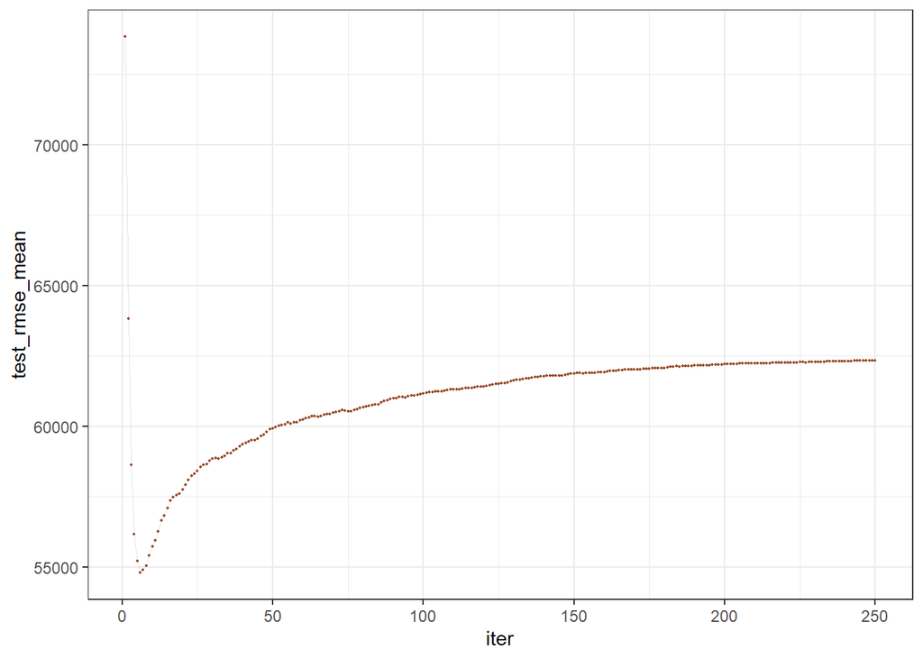

```r
library(xgboost); library(caret)
set.seed(617)
tune_nrounds = xgb.cv(data=as.matrix(train_input),
                      label = train$earn,
                      nrounds=250,
                      nfold = 5,
                      verbose = 0)

ggplot(data=tune_nrounds$evaluation_log, aes(x=iter, y=test_rmse_mean))+
  geom_point(size=0.4, color='sienna')+
  geom_line(size=0.1, alpha=0.1)+
  theme_bw()
```

As is obvious from the above chart, the optimal nrounds is a rather small number

```r
which.min(tune_nrounds$evaluation_log$test_rmse_mean)
```

```
## [1] 6
```

Next, we use xgboost to fit the train data with nrounds = 6 and apply the model to the test data.

```r
xgboost2= xgboost(data=as.matrix(train_input),
                  label = train$earn,
                  nrounds=6,
                  verbose = 0)
pred = predict(xgboost2,
               newdata=as.matrix(test_input))
rmse_xgboost = sqrt(mean((pred - test$earn)^2)); rmse_xgboost
```

```
## [1] 51597.19
```

Now, it is possible to tune an xgboost model using other parameters such as eta, max_depth, and gamma using the `train` function from library(caret)

# Results

Here are the results from the different models that were run

```r
data.frame(models = c('Tree', 'Maximal Tree', 'Tuned Tree', 'Bag','Forest','Tuned Forest','Ranger','Tuned Ranger','Boost','Tuned Boost','XGBoost'),
           RMSE = c(rmse_tree, rmse_maximalTree, rmse_cvTree, rmse_bag, rmse_forest, rmse_cv_forest, rmse_forest_ranger,
rmse_cv_forest_ranger, rmse_boost, rmse_cv_boost, rmse_xgboost))
```

| models | RMSE |
| --- | --- |
| Tree | 53456.15 |
| Maximal Tree | 57082.55 |
| Tuned Tree | 54198.35 |
| Bag | 53486.83 |
| Forest | 50062.28 |
| Tuned Forest | 52363.92 |
| Ranger | 52381.18 |
| Tuned Ranger | 51741.44 |
| Boost | 50876.59 |
| Tuned Boost | 51234.84 |

[output cut: 1 more lines]